# ps4

Sijun Zhang 89934761

2019/11/18

In Problem Set 4, all confidence intervals are calculated at the level 0.05 and the lwr indicates the 2.5% lower bound and the upr indicates the 97.5% upper bound for each confidence interval.

# Question 1

Firstly, the csv data file generated by ps2_q3.R is imported to the .do script as the data table for manuplation. The confidence interval is calculated at level 0.05

```stata
import delimited df_ps4_q1.csv

replace auc = max(auc,1)

replace tot_dist = log(tot_dist)
replace max_abs_dev = log(max_abs_dev)
replace avg_abs_dev = log(avg_abs_dev)
replace auc = log(auc)

encode condition, generate(condition_i)
replace condition_i = (-1)*condition_i+2
encode exemplar, generate(exemplar_i)

mixed tot_dist condition_i ||_all:R.subject_nr ||_all:R.exemplar
matrix b1 = e(b)
matrix v1 = e(V)

mixed max_abs_dev condition_i ||_all:R.subject_nr ||_all:R.exemplar
matrix b2 = e(b)
matrix v2 = e(V)

mixed avg_abs_dev condition_i ||_all:R.subject_nr ||_all:R.exemplar
matrix b3 = e(b)
matrix v3 = e(V)

mixed auc condition_i ||_all:R.subject_nr ||_all:R.exemplar
matrix b4 = e(b)
matrix v4 = e(V)

mata
b1_mata = st_matrix("b1")
b2_mata = st_matrix("b2")
b3_mata = st_matrix("b3")
b4_mata = st_matrix("b4")

v1_mata = st_matrix("v1")
v2_mata = st_matrix("v2")
v3_mata = st_matrix("v3")
v4_mata = st_matrix("v4")

a1 = (exp(b1_mata[1,1]), exp(b1_mata[1,1]-sqrt(v1_mata[1,1])*1.96),  exp(b1_mata[1,1]+sqrt(v1_mata[1,1])*1.96))
a2 = (exp(b2_mata[1,1]), exp(b2_mata[1,1]-sqrt(v2_mata[1,1])*1.96),  exp(b2_mata[1,1]+sqrt(v2_mata[1,1])*1.96))
a3 = (exp(b3_mata[1,1]), exp(b3_mata[1,1]-sqrt(v3_mata[1,1])*1.96),  exp(b3_mata[1,1]+sqrt(v3_mata[1,1])*1.96))
a4 = (exp(b4_mata[1,1]), exp(b4_mata[1,1]-sqrt(v4_mata[1,1])*1.96),  exp(b4_mata[1,1]+sqrt(v4_mata[1,1])*1.96))

a = a1\a2\a3\a4

st_matrix("re", a)

end
matrix rownames re=Total_Distance Maximum_Absolute_Deviation Average_Absolute_Deviation AUC
matrix colnames re=Relative_effect_est Relative_effect_lwr Relative_effect_upr

putexcel set ps4_q1.xls, replace
putexcel A1 = matrix(re), names

* Script Cleanup: --------------------------------------------------------------
log close
exit
```

```r
library(readxl)
ps4_q1 = read_excel("ps4_q1.xls",sheet=1,na="NA")
```

```
## * `` -> ...1
```

```r
knitr::kable(ps4_q1)
```

| …1 | Relative_effect_est | Relative_effect_lwr | Relative_effect_upr |
| --- | --- | --- | --- |
| Total_Distance | 1.175112 | 1.092844 | 1.263572 |
| Maximum_Absolute_Deviation | 1.665213 | 1.334694 | 2.077579 |
| Average_Absolute_Deviation | 1.917491 | 1.486285 | 2.473799 |
| AUC | 1.418568 | 1.162286 | 1.731359 |

From the above table, we find the coefficient of Condition on “the average absolute deviation of the observed trajectory from the direct path” is the maximum. Moreover, the expectation of average absolute deviation is also the smallest, which means the unit change in Condition variable is more influential in changing the distribution of average absolute deviation. Considering the two facts in average absolute deviation, we can conclude that the Condition has largest effect on the average absolute deviation. Moreover, the 95% confidence intervals are obtained in the above table.

# Question 2

In this question, we aims to find which census division has the largest disparity between urban and rural areas in terms of the proportion of homes with internet access. And the result is stored in a csv file.

```stata
clear                   // Start clean

* Data Prep: -------------------------------------------------------------------
// data prep
*? Maybe tidy up over-long line with locals?
local recs_file "recs2015_public_v4.csv"
local recs_url = "https://www.eia.gov/consumption/residential/data/2015/csv/"
capture confirm file `recs_file'
if _rc==0 {
  display "Loading local file"
  import delimited `recs_file', clear
}
else {
  display "Download file and create local copy"
  import delimited `recs_url'`recs_file', clear
  export delimited `recs_file'
}

encode uatyp10, generate(uatyp10_i)
replace uatyp10_i = 1 if uatyp10_i==3

label define division_i 1 "New England" 2 "Middle Atlantic" 3 "East North Central" 4 "West North Central" 5 "South Atlantic" 6 "East South Central" 7 "West South Central" 8 "Mountain North" 9 "Mountain South" 10 "Pacific"
label values division division_i

preserve

local vars = "uatyp10_i division internet"
keep doeid nweight `vars'
save recs2015_prop_est.dta, replace

// in order to merge the nweight and brrwt values
restore
keep doeid brrwt1-brrwt96 `vars'
reshape long brrwt, i(doeid) j(repl)
merge m:1 doeid using recs2015_prop_est.dta

// calc the proportion of homes with internet
generate brrwt_with_internet = internet*brrwt
generate nw_with_internet = internet*nweight
collapse (sum) brrwt brrwt_with_internet nweight nw_with_internet, by(division uatyp10_i repl)
generate prop_repl = brrwt_with_internet/brrwt
generate prop = nw_with_internet/nweight
drop brrwt brrwt_with_internet
drop nweight nw_with_internet

// calc the confidence interval using brrwt replications
reshape wide prop_repl prop,i(division repl) j(uatyp10_i)
generate diff_prop = prop1-prop2
generate diff_prop_repl = prop_repl1 - prop_repl2
generate rsq_prop1 = (prop1-prop_repl1)^2/(1-0.5)^2
generate rsq_prop2 = (prop2-prop_repl2)^2/(1-0.5)^2
generate rsq_prop_diff = (diff_prop-diff_prop_repl)^2/(1-0.5)^2
collapse (mean) prop1 prop2 diff_prop rsq_prop1 rsq_prop2 rsq_prop_diff , by(division)

generate diff_prop_lwr = diff_prop - 1.96*sqrt(rsq_prop_diff)
generate diff_prop_upr = diff_prop + 1.96*sqrt(rsq_prop_diff)

rename stderr_prop1 rsq_prop1
replace stderr_prop1 = sqrt(stderr_prop1)
rename stderr_prop2 rsq_prop2
replace stderr_prop2 = sqrt(stderr_prop2)
rename stderr_diff_prop rsq_prop_diff
replace stderr_diff_prop = sqrt(stderr_diff_prop)
export delimited recs_prop_with_internet.csv, replace
```

```r
ps4_q2 = read.delim("recs_prop_with_internet.csv", sep = ",")
names(ps4_q2) = c("division", "prop_urb", "prop_rur", "diff_prop","SE_prop_urb", "SE_prop_rur", "SE_diff_prop", "diff_prop_lwr", "diff_prop_upr")
options(digits = 4)
knitr::kable(ps4_q2)
```

| division | prop_urb | prop_rur | diff_prop | SE_prop_urb | SE_prop_rur | SE_diff_prop | diff_prop_lwr | diff_prop_upr |
| --- | --- | --- | --- | --- | --- | --- | --- | --- |
| New England | 0.8757 | 0.8579 | 0.0178 | 0.0259 | 0.0175 | 0.0218 | -0.0248 | 0.0604 |
| Middle Atlantic | 0.8934 | 0.9129 | -0.0195 | 0.0280 | 0.0305 | 0.0364 | -0.0909 | 0.0519 |
| East North Central | 0.8625 | 0.8621 | 0.0004 | 0.0127 | 0.0233 | 0.0273 | -0.0530 | 0.0539 |
| West North Central | 0.8800 | 0.8033 | 0.0768 | 0.0172 | 0.0451 | 0.0517 | -0.0245 | 0.1781 |
| South Atlantic | 0.8530 | 0.8204 | 0.0326 | 0.0136 | 0.0294 | 0.0347 | -0.0354 | 0.1005 |
| East South Central | 0.7836 | 0.6903 | 0.0933 | 0.0399 | 0.0282 | 0.0547 | -0.0140 | 0.2006 |
| West South Central | 0.8161 | 0.7650 | 0.0510 | 0.0265 | 0.0223 | 0.0377 | -0.0230 | 0.1250 |
| Mountain North | 0.8742 | 0.8193 | 0.0550 | 0.0277 | 0.0414 | 0.0596 | -0.0619 | 0.1719 |
| Mountain South | 0.8527 | 0.6675 | 0.1852 | 0.0201 | 0.0433 | 0.0578 | 0.0719 | 0.2984 |
| Pacific | 0.8871 | 0.8528 | 0.0343 | 0.0129 | 0.0400 | 0.0405 | -0.0451 | 0.1137 |

```r
ps4_q2[which( ps4_q2[,"diff_prop"] == max(ps4_q2[,"diff_prop"])),1]
```

```
## [1] Mountain South
## 10 Levels: East North Central East South Central ... West South Central
```

```r
library(tidyverse)
```

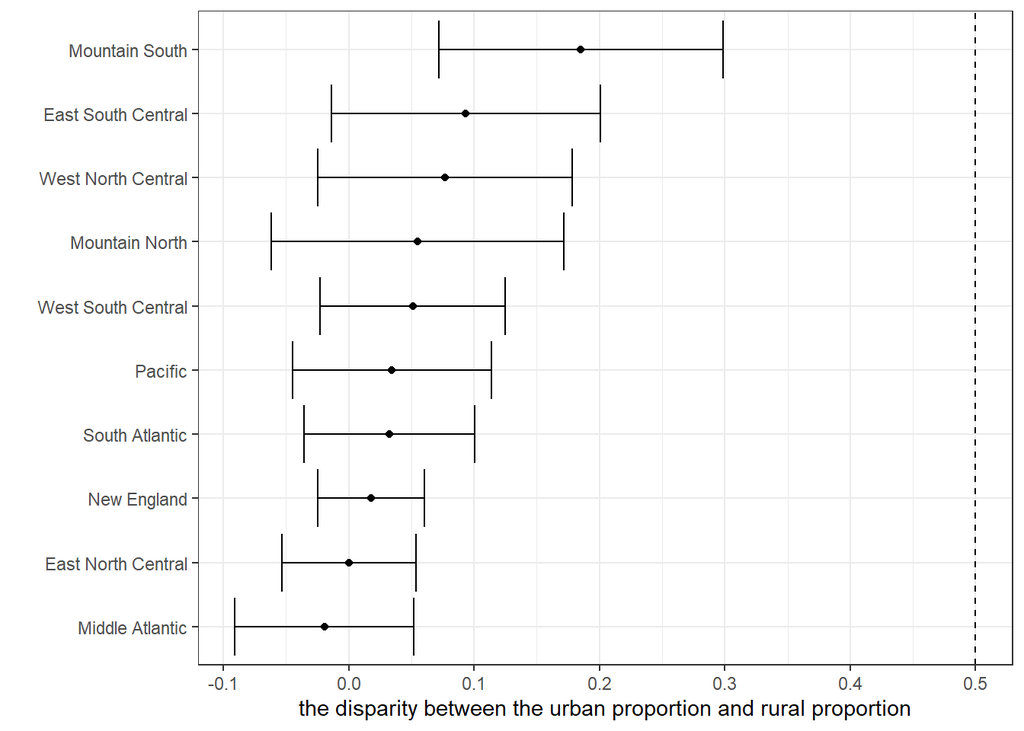

```r
ps4_q2 %>%
  arrange( diff_prop ) %>%
  mutate( measure = factor(division, levels = unique(division) ) ) %>%
  ggplot( aes( y = measure, x = diff_prop) ) +
  geom_point() +
  geom_errorbarh( aes(xmin = diff_prop_lwr, xmax = diff_prop_upr) ) +
  geom_vline( xintercept = 0.5, lty = 'dashed') +
  xlab('the disparity between the urban proportion and rural proportion') +
  ylab('') +
  theme_bw()
```

# Question 3

## Part a

In this part, the binary indicators are all labelled to be factor variables.

```stata
import sasxport5 DEMO_D, clear
keep seqn riagendr ridageyr indfmpir ridexmon
// find if it in winter
generate if_winter = ridexmon
generate age = ridageyr
generate gender = riagendr
generate pir = indfmpir
drop riagendr ridageyr indfmpir ridexmon
save demo_d.dta, replace

import sasxport5 DR1TOT_D, clear

keep seqn dr1day dr1_320z
// find if it was weekday
generate in_weekday1 = 1 if dr1day <= 6 & dr1day >=2
replace in_weekday1 = 0 if dr1day == 7 | dr1day == 1
// find if the responent has drank water
generate drank_water1 = 0 if dr1_320z == 0
replace drank_water1 = 1 if dr1_320z > 0
replace drank_water1 = . if dr1_320z == .
drop dr1_320z
save dr1tot_d.dta, replace

import sasxport5 DR2TOT_D, clear
keep seqn dr2day dr2_320z
// find if it was weekday
generate in_weekday2 = 1 if dr2day <= 6 & dr2day >=2
replace in_weekday2 = 0 if dr2day == 7 | dr2day == 1
// find if the responent has drank water
generate drank_water2 = 0 if dr2_320z == 0
replace drank_water = 1 if dr2_320z > 0
replace drank_water2 = . if dr2_320z == .
drop dr2_320z
merge m:1 seqn using dr1tot_d.dta
drop _merge

generate drday1 = dr1day
generate drday2 = dr2day
drop dr1day dr2day
reshape long in_weekday drank_water drday, i(seqn) j(svy_day)

merge m:1 seqn using demo_d.dta
drop _merge

label define winter_i 1 "in winter" 2 "not in winter"
label define drank_water_i 1 "has drank water" 0 "not drank water"
label define week_i 1 "weekday" 0 "weekend"
label define gender_i 1 "Male" 2 "Female"

label values in_weekday week_i
label values drank_water drank_water_i
label values if_winter winter_i
label values gender gender_i

export delimited ps4_q3_a_df.csv, replace
```

```r
ps4_q3_a = read.delim("ps4_q3_a_df.csv", sep = ",")
options(digits = 4)
knitr::kable(head(ps4_q3_a) )
```

| seqn | svy_day | in_weekday | drank_water | drday | if_winter | age | gender | pir |
| --- | --- | --- | --- | --- | --- | --- | --- | --- |
| 31127 | 1 | weekend | not drank water | 7 | not in winter | 0 | Male | 0.75 |
| 31127 | 2 | weekend | not drank water | 1 | not in winter | 0 | Male | 0.75 |
| 31128 | 1 | weekday | not drank water | 6 | in winter | 11 | Female | 0.77 |
| 31128 | 2 | weekday | has drank water | 2 | in winter | 11 | Female | 0.77 |
| 31129 | 1 | weekday | has drank water | 2 | not in winter | 15 | Male | 2.71 |
| 31129 | 2 | weekend | has drank water | 1 | not in winter | 15 | Male | 2.71 |

## Part b

```stata
generate missing = 0
replace missing = 1 if in_weekday == . | drank_water == . | age == . | gender == . | pir == . | if_winter == .

generate fid = 0
save ps4_q3_df_missing.dta, replace

// calc the mean of pir and age
drop if missing == 1
collapse (mean) pir age
generate mean_pir = pir
generate mean_age = age
drop pir age
export delimited mean_pir_age.csv, replace

generate fid = 0
merge 1:m fid using ps4_q3_df_missing.dta

// Centering and decading to as it is continuous
replace age = (age - mean_age) / 10
replace pir = pir - mean_pir

drop mean_age mean_pir _merge

export delimited ps4_q3_b_df.csv, replace
```

```r
ps4_q3_b = read.delim("ps4_q3_b_df.csv", sep = ",")
options(digits = 4)
knitr::kable(head(ps4_q3_b) )
```

| fid | seqn | svy_day | in_weekday | drank_water | drday | if_winter | age | gender | pir | missing |
| --- | --- | --- | --- | --- | --- | --- | --- | --- | --- | --- |
| 0 | 31127 | 1 | weekend | not drank water | 7 | not in winter | -2.798 | Male | -1.6452 | 0 |
| 0 | 31127 | 2 | weekend | not drank water | 1 | not in winter | -2.798 | Male | -1.6452 | 0 |
| 0 | 31128 | 1 | weekday | not drank water | 6 | in winter | -1.698 | Female | -1.6252 | 0 |
| 0 | 31128 | 2 | weekday | has drank water | 2 | in winter | -1.698 | Female | -1.6252 | 0 |
| 0 | 31129 | 1 | weekday | has drank water | 2 | not in winter | -1.298 | Male | 0.3148 | 0 |
| 0 | 31129 | 2 | weekend | has drank water | 1 | not in winter | -1.298 | Male | 0.3148 | 0 |

In this problem, the unit of age is decades, but variable age is still continuous and has a mean of 0 among no missing value data.

```r
ps4_q3_b_mean = read.delim("mean_pir_age.csv", sep = ",")
options(digits = 8)
knitr::kable(head(ps4_q3_b_mean) )
```

| mean_pir | mean_age |
| --- | --- |
| 2.3952346 | 27.975784 |

## Part c

```stata
save ps4_q3_log_df.dta, replace
// only use day 1 data
drop if svy_day == 2 | svy_day == .
drop if missing == 1
logistic drank_water in_weekday if_winter c.age##c.age gender c.pir
matrix b1 = e(b)
matrix v1 = e(V)

margins, dydx(*)
matrix b2 = r(b)
matrix v2 = r(V)

mata
    b1_m = st_matrix("b1")
    b1_m = b1_m[1],b1_m[2],b1_m[3],b1_m[5],b1_m[6],b1_m[4]
    v1_m = st_matrix("v1")
    v1_m = diagonal(v1_m)'
    v1_m = v1_m[1],v1_m[2],v1_m[3],v1_m[5],v1_m[6],b1_m[4]
    b2_m = st_matrix("b2"),(.)
    v2_m = st_matrix("v2")
    v2_m = diagonal(v2_m)',(.)

    a1 = exp(b1_m - 1.96*sqrt(v1_m))
    b1 = exp(b1_m + 1.96*sqrt(v1_m))
    re1 = a1\b1

    a2 = (b2_m - 1.96*sqrt(v2_m))
    b2 = (b2_m + 1.96*sqrt(v2_m))
    re2 = a2\b2

    re = exp(b1_m)\re1\b2_m\re2

    st_matrix("re_c",re)

end

matrix rownames re_c=Odds_ratios Odds_ratios_lwr Odds_ratios_upr Marginal_effect Marginal_effect_lwr Marginal_effect_upr
matrix colnames re_c=in_weekday if_winter age gender pir age^2

putexcel set ps4_q3_c.xls, replace
putexcel A1 = matrix(re_c), names
```

```r
ps4_q3_c = read_excel("ps4_q3_c.xls",sheet=1,na="NA")
```

```
## * `` -> ...1
```

```r
knitr::kable(ps4_q3_c)
```

| …1 | in_weekday | if_winter | age | gender | pir | age^2 |
| --- | --- | --- | --- | --- | --- | --- |
| Odds_ratios | 1.13013637 | 1.10980804 | 1.15818199 | 1.33265955 | 1.09384890 | 0.97373228 |
| Odds_ratios_lwr | 1.02774566 | 1.00991703 | 1.12831459 | 1.21330492 | 1.06038751 | 0.34062927 |
| Odds_ratios_upr | 1.24272790 | 1.21957929 | 1.18884000 | 1.46375528 | 1.12836619 | 2.78353808 |
| Marginal_effect | 0.02400408 | 0.02044262 | 0.03165433 | 0.05634712 | 0.01760061 | NA |
| Marginal_effect_lwr | 0.00539069 | 0.00195126 | 0.02568416 | 0.03805279 | 0.01153741 | NA |
| Marginal_effect_upr | 0.04261748 | 0.03893397 | 0.03762451 | 0.07464146 | 0.02366380 | NA |

The odds ratio and average marginal effects for each variable are shown above, which also includes the 95% confidence interval of odds ratio and average marginal effect.

## Part d

```stata
use ps4_q3_log_df, clear
drop if missing == 1
meglm drank_water in_weekday if_winter c.age##c.age gender c.pir ||seqn:, family(binomial) link(logit)
matrix b1 = e(b)
matrix v1 = e(V)

margins, dydx(*)
matrix b2 = r(b)
matrix v2 = r(V)

mata
    b1_m = st_matrix("b1")
    b1_m = b1_m[1],b1_m[2],b1_m[3],b1_m[5],b1_m[6],b1_m[4]
    v1_m = st_matrix("v1")
    v1_m = diagonal(v1_m)'
    v1_m = v1_m[1],v1_m[2],v1_m[3],v1_m[5],v1_m[6],v1_m[4]
    b2_m = st_matrix("b2"),(.)
    v2_m = st_matrix("v2")
    v2_m = diagonal(v2_m)',(.)

    a1 = (b1_m - 1.96*sqrt(v1_m))
    b1 = (b1_m + 1.96*sqrt(v1_m))
    re1 = exp(a1)\exp(b1)
    re3 = a1\b1

    a2 = (b2_m - 1.96*sqrt(v2_m))
    b2 = (b2_m + 1.96*sqrt(v2_m))
    re2 = a2\b2

    re = exp(b1_m)\re1\b2_m\re2\b1_m\re3

    st_matrix("re_d",re)

end

matrix rownames re_d=Odds_ratios Odds_ratios_lwr Odds_ratios_upr Marginal_effect Marginal_effect_lwr Marginal_effect_upr Coefficients Coefficients_lwr Coefficients_lwr
matrix colnames re_d=in_weekday if_winter age gender pir age^2

putexcel set ps4_q3_d.xls, replace
putexcel A1 = matrix(re_d), names
```

```r
ps4_q3_d = read_excel("ps4_q3_d.xls",sheet=1,na="NA")
```

```
## * `` -> ...1
```

```r
knitr::kable(ps4_q3_d)
```

| …1 | in_weekday | if_winter | age | gender | pir | age^2 |
| --- | --- | --- | --- | --- | --- | --- |
| Odds_ratios | 1.23997947 | 1.07781793 | 1.36247825 | 1.75791484 | 1.17901763 | 0.95507806 |
| Odds_ratios_lwr | 1.10901761 | 0.93689837 | 1.30828144 | 1.52708791 | 1.12590614 | 0.94204654 |
| Odds_ratios_upr | 1.38640637 | 1.23993330 | 1.41892022 | 2.02363240 | 1.23463450 | 0.96828985 |
| Marginal_effect | 0.02304188 | 0.00802774 | 0.03590087 | 0.06043184 | 0.01764139 | NA |
| Marginal_effect_lwr | 0.01111321 | -0.00697934 | 0.03093848 | 0.04554587 | 0.01275459 | NA |
| Marginal_effect_upr | 0.03497054 | 0.02303482 | 0.04086326 | 0.07531782 | 0.02252820 | NA |
| Coefficients | 0.21509482 | 0.07493856 | 0.30930529 | 0.56412835 | 0.16468157 | -0.04596220 |
| Coefficients_lwr | 0.10347459 | -0.06518046 | 0.26871440 | 0.42336260 | 0.11858817 | -0.05970060 |
| Coefficients_lwr | 0.32671506 | 0.21505759 | 0.34989617 | 0.70489411 | 0.21077498 | -0.03222381 |

To answer the overall question: Yes, in the US, people are more likely to drink water on a weekday than on a weekend day. The odds ratios for that are 1.13 and 1.24 respectively in the above models.